# Risk Factor Analysis

## Outcome Variable

**Outcome Variable:** haz

## Predictor Variables

**Intervention Variable:** hfoodsec

**Adjustment Set:**

- arm
- sex
- W_mage
- meducyrs
- feducyrs
- hhwealth_quart
- vagbrth
- W_nrooms
- W_nchldlt5
- brthmon
- W_parity
- impfloor
- impsan
- safeh20
- delta_W_mage
- delta_meducyrs
- delta_feducyrs
- delta_hhwealth_quart
- delta_vagbrth
- delta_W_nrooms
- delta_W_nchldlt5
- delta_brthmon
- delta_W_parity
- delta_impfloor
- delta_impsan
- delta_safeh20

## Stratifying Variables

The analysis was stratified on these variable(s):

- agecat
- studyid
- country

## Data Summary

| agecat | studyid | country | hfoodsec | n_cell | n | outcome_variable |
| --- | --- | --- | --- | --- | --- | --- |
| Birth | GMS-Nepal | NEPAL | Food Secure | 477 | 672 | haz |
| Birth | GMS-Nepal | NEPAL | Mildly Food Insecure | 106 | 672 | haz |
| Birth | GMS-Nepal | NEPAL | Food Insecure | 89 | 672 | haz |
| Birth | JiVitA-3 | BANGLADESH | Food Secure | 6951 | 14364 | haz |
| Birth | JiVitA-3 | BANGLADESH | Mildly Food Insecure | 4877 | 14364 | haz |
| Birth | JiVitA-3 | BANGLADESH | Food Insecure | 2536 | 14364 | haz |
| Birth | JiVitA-4 | BANGLADESH | Food Secure | 1433 | 2810 | haz |
| Birth | JiVitA-4 | BANGLADESH | Mildly Food Insecure | 1018 | 2810 | haz |
| Birth | JiVitA-4 | BANGLADESH | Food Insecure | 359 | 2810 | haz |
| Birth | MAL-ED | BANGLADESH | Food Secure | 144 | 172 | haz |
| Birth | MAL-ED | BANGLADESH | Mildly Food Insecure | 4 | 172 | haz |
| Birth | MAL-ED | BANGLADESH | Food Insecure | 24 | 172 | haz |
| Birth | MAL-ED | BRAZIL | Food Secure | 0 | 28 | haz |
| Birth | MAL-ED | BRAZIL | Mildly Food Insecure | 4 | 28 | haz |
| Birth | MAL-ED | BRAZIL | Food Insecure | 24 | 28 | haz |
| Birth | MAL-ED | INDIA | Food Secure | 34 | 37 | haz |
| Birth | MAL-ED | INDIA | Mildly Food Insecure | 1 | 37 | haz |
| Birth | MAL-ED | INDIA | Food Insecure | 2 | 37 | haz |
| Birth | MAL-ED | NEPAL | Food Secure | 10 | 14 | haz |
| Birth | MAL-ED | NEPAL | Mildly Food Insecure | 1 | 14 | haz |
| Birth | MAL-ED | NEPAL | Food Insecure | 3 | 14 | haz |
| Birth | MAL-ED | PERU | Food Secure | 24 | 91 | haz |
| Birth | MAL-ED | PERU | Mildly Food Insecure | 23 | 91 | haz |
| Birth | MAL-ED | PERU | Food Insecure | 44 | 91 | haz |
| Birth | MAL-ED | SOUTH AFRICA | Food Secure | 45 | 88 | haz |
| Birth | MAL-ED | SOUTH AFRICA | Mildly Food Insecure | 9 | 88 | haz |
| Birth | MAL-ED | SOUTH AFRICA | Food Insecure | 34 | 88 | haz |
| Birth | NIH-Birth | BANGLADESH | Food Secure | 90 | 608 | haz |
| Birth | NIH-Birth | BANGLADESH | Mildly Food Insecure | 478 | 608 | haz |
| Birth | NIH-Birth | BANGLADESH | Food Insecure | 40 | 608 | haz |

[output cut: 69 more lines]

The following strata were considered:

- agecat: 24 months, studyid: GMS-Nepal, country: NEPAL
- agecat: 24 months, studyid: JiVitA-3, country: BANGLADESH
- agecat: 24 months, studyid: JiVitA-4, country: BANGLADESH
- agecat: 24 months, studyid: MAL-ED, country: BANGLADESH
- agecat: 24 months, studyid: MAL-ED, country: BRAZIL
- agecat: 24 months, studyid: MAL-ED, country: INDIA
- agecat: 24 months, studyid: MAL-ED, country: NEPAL
- agecat: 24 months, studyid: MAL-ED, country: PERU
- agecat: 24 months, studyid: MAL-ED, country: SOUTH AFRICA
- agecat: 24 months, studyid: NIH-Birth, country: BANGLADESH
- agecat: 24 months, studyid: NIH-Crypto, country: BANGLADESH
- agecat: 6 months, studyid: GMS-Nepal, country: NEPAL
- agecat: 6 months, studyid: JiVitA-3, country: BANGLADESH
- agecat: 6 months, studyid: JiVitA-4, country: BANGLADESH
- agecat: 6 months, studyid: MAL-ED, country: BANGLADESH
- agecat: 6 months, studyid: MAL-ED, country: BRAZIL
- agecat: 6 months, studyid: MAL-ED, country: INDIA
- agecat: 6 months, studyid: MAL-ED, country: NEPAL
- agecat: 6 months, studyid: MAL-ED, country: PERU
- agecat: 6 months, studyid: MAL-ED, country: SOUTH AFRICA
- agecat: 6 months, studyid: NIH-Birth, country: BANGLADESH
- agecat: 6 months, studyid: NIH-Crypto, country: BANGLADESH
- agecat: Birth, studyid: GMS-Nepal, country: NEPAL
- agecat: Birth, studyid: JiVitA-3, country: BANGLADESH
- agecat: Birth, studyid: JiVitA-4, country: BANGLADESH
- agecat: Birth, studyid: MAL-ED, country: BANGLADESH
- agecat: Birth, studyid: MAL-ED, country: BRAZIL
- agecat: Birth, studyid: MAL-ED, country: INDIA
- agecat: Birth, studyid: MAL-ED, country: NEPAL
- agecat: Birth, studyid: MAL-ED, country: PERU
- agecat: Birth, studyid: MAL-ED, country: SOUTH AFRICA
- agecat: Birth, studyid: NIH-Birth, country: BANGLADESH
- agecat: Birth, studyid: NIH-Crypto, country: BANGLADESH

### Dropped Strata

Some strata were dropped due to rare outcomes:

- agecat: Birth, studyid: MAL-ED, country: BANGLADESH
- agecat: Birth, studyid: MAL-ED, country: BRAZIL
- agecat: Birth, studyid: MAL-ED, country: INDIA
- agecat: Birth, studyid: MAL-ED, country: NEPAL
- agecat: 6 months, studyid: MAL-ED, country: BANGLADESH
- agecat: 6 months, studyid: MAL-ED, country: BRAZIL
- agecat: 24 months, studyid: MAL-ED, country: BANGLADESH
- agecat: 24 months, studyid: MAL-ED, country: BRAZIL

## Methods Detail

We’re interested in the causal parameters $E[Y_a]$ for all values of $a \in \mathcal{A}$. These parameters represent the mean outcome if, possibly contrary to fact, we intervened to set all units to have $A=a$. Under the randomization and positivity assumptions, these are identified by the statistical parameters $\psi_a=E_W[E_{Y|A,W}(Y|A=a,W)]$. In addition, we’re interested in the mean of $Y$, $E[Y]$ under no intervention (the observed mean). We will estimate these parameters by using SuperLearner to fit the relevant likelihood factors – $E_{Y|A,W}(Y|A=a,W)$ and $p(A=a|W)$, and then updating our likelihood fit using a joint TMLE.

For unadjusted analyses ($W=\{\}$), initial likelihoods were estimated using Lrnr_glm to estimate the simple $E(Y|A)$ and Lrnr_mean to estimate $p(A)$. For adjusted analyses, a small library containing Lrnr_glmnet, Lrnr_xgboost, and Lrnr_mean was used.

Having estimated these parameters, we will then use the delta method to estimate relative risks and attributable risks relative to a prespecified baseline level of $A$.

# Results Detail

## Results Plots

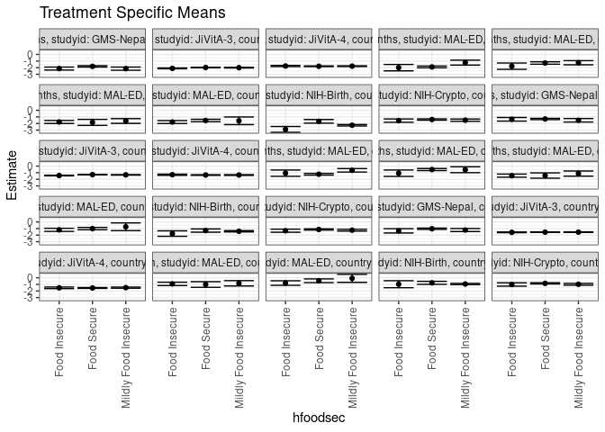

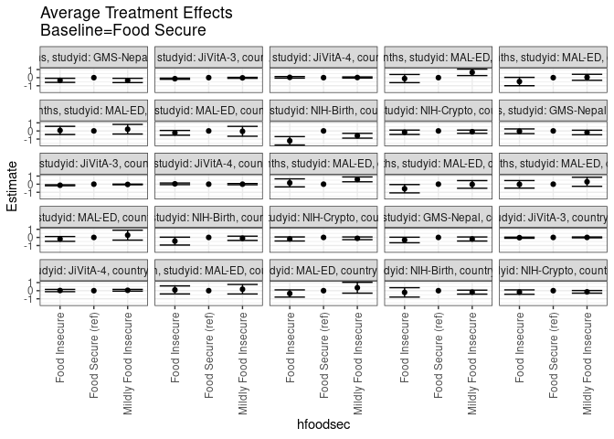

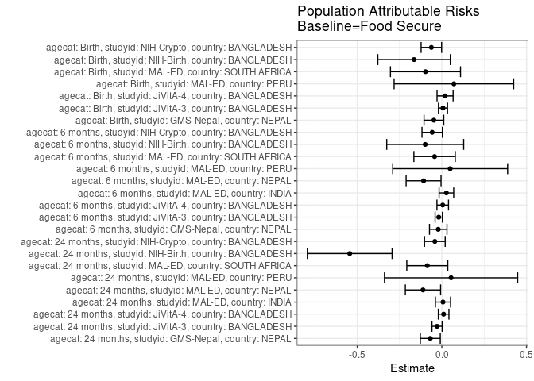

## Results Table

### Parameter: TSM

| agecat | studyid | country | intervention_level | baseline_level | estimate | ci_lower | ci_upper |
| --- | --- | --- | --- | --- | --- | --- | --- |
| Birth | GMS-Nepal | NEPAL | Food Secure | NA | -1.0321668 | -1.1294866 | -0.9348469 |
| Birth | GMS-Nepal | NEPAL | Mildly Food Insecure | NA | -1.2265956 | -1.4555897 | -0.9976016 |
| Birth | GMS-Nepal | NEPAL | Food Insecure | NA | -1.3470745 | -1.6727878 | -1.0213612 |
| Birth | JiVitA-3 | BANGLADESH | Food Secure | NA | -1.5442164 | -1.5781612 | -1.5102716 |
| Birth | JiVitA-3 | BANGLADESH | Mildly Food Insecure | NA | -1.5425075 | -1.5828837 | -1.5021314 |
| Birth | JiVitA-3 | BANGLADESH | Food Insecure | NA | -1.5758417 | -1.6322573 | -1.5194262 |
| Birth | JiVitA-4 | BANGLADESH | Food Secure | NA | -1.5438737 | -1.6116672 | -1.4760802 |
| Birth | JiVitA-4 | BANGLADESH | Mildly Food Insecure | NA | -1.4960517 | -1.5806861 | -1.4114172 |
| Birth | JiVitA-4 | BANGLADESH | Food Insecure | NA | -1.5238088 | -1.6439021 | -1.4037154 |
| Birth | MAL-ED | PERU | Food Secure | NA | -1.0200927 | -1.4439505 | -0.5962349 |
| Birth | MAL-ED | PERU | Mildly Food Insecure | NA | -0.8390939 | -1.2425214 | -0.4356663 |
| Birth | MAL-ED | PERU | Food Insecure | NA | -0.9259782 | -1.1814165 | -0.6705399 |
| Birth | MAL-ED | SOUTH AFRICA | Food Secure | NA | -0.4535556 | -0.7370575 | -0.1700536 |
| Birth | MAL-ED | SOUTH AFRICA | Mildly Food Insecure | NA | -0.0888889 | -0.6955550 | 0.5177773 |
| Birth | MAL-ED | SOUTH AFRICA | Food Insecure | NA | -0.8005882 | -1.1433809 | -0.4577955 |
| Birth | NIH-Birth | BANGLADESH | Food Secure | NA | -0.7669489 | -0.9912400 | -0.5426578 |
| Birth | NIH-Birth | BANGLADESH | Mildly Food Insecure | NA | -0.9460540 | -1.0462030 | -0.8459050 |
| Birth | NIH-Birth | BANGLADESH | Food Insecure | NA | -0.9764984 | -1.5074620 | -0.4455348 |
| Birth | NIH-Crypto | BANGLADESH | Food Secure | NA | -0.8475076 | -0.9358331 | -0.7591822 |
| Birth | NIH-Crypto | BANGLADESH | Mildly Food Insecure | NA | -0.9875640 | -1.1270431 | -0.8480848 |
| Birth | NIH-Crypto | BANGLADESH | Food Insecure | NA | -1.0193767 | -1.2743197 | -0.7644336 |
| 6 months | GMS-Nepal | NEPAL | Food Secure | NA | -1.3207634 | -1.4144431 | -1.2270837 |
| 6 months | GMS-Nepal | NEPAL | Mildly Food Insecure | NA | -1.5157368 | -1.7797219 | -1.2517517 |
| 6 months | GMS-Nepal | NEPAL | Food Insecure | NA | -1.3646544 | -1.6398480 | -1.0894608 |
| 6 months | JiVitA-3 | BANGLADESH | Food Secure | NA | -1.2947359 | -1.3258698 | -1.2636020 |
| 6 months | JiVitA-3 | BANGLADESH | Mildly Food Insecure | NA | -1.3265820 | -1.3620411 | -1.2911229 |
| 6 months | JiVitA-3 | BANGLADESH | Food Insecure | NA | -1.4285208 | -1.4810167 | -1.3760250 |
| 6 months | JiVitA-4 | BANGLADESH | Food Secure | NA | -1.3498144 | -1.4014740 | -1.2981548 |
| 6 months | JiVitA-4 | BANGLADESH | Mildly Food Insecure | NA | -1.3503312 | -1.4095111 | -1.2911514 |
| 6 months | JiVitA-4 | BANGLADESH | Food Insecure | NA | -1.3057997 | -1.3947848 | -1.2168146 |
| 6 months | MAL-ED | INDIA | Food Secure | NA | -1.2287544 | -1.3589893 | -1.0985195 |
| 6 months | MAL-ED | INDIA | Mildly Food Insecure | NA | -0.6360000 | -0.9019405 | -0.3700595 |
| 6 months | MAL-ED | INDIA | Food Insecure | NA | -1.0694118 | -1.5456747 | -0.5931488 |
| 6 months | MAL-ED | NEPAL | Food Secure | NA | -0.5182829 | -0.6774613 | -0.3591045 |
| 6 months | MAL-ED | NEPAL | Mildly Food Insecure | NA | -0.5479683 | -0.9909484 | -0.1049881 |
| 6 months | MAL-ED | NEPAL | Food Insecure | NA | -1.0779377 | -1.5653859 | -0.5904896 |
| 6 months | MAL-ED | PERU | Food Secure | NA | -1.4275014 | -1.8299485 | -1.0250542 |
| 6 months | MAL-ED | PERU | Mildly Food Insecure | NA | -1.1322273 | -1.5241635 | -0.7402912 |
| 6 months | MAL-ED | PERU | Food Insecure | NA | -1.4475661 | -1.6846366 | -1.2104956 |
| 6 months | MAL-ED | SOUTH AFRICA | Food Secure | NA | -1.0108600 | -1.1870844 | -0.8346357 |
| 6 months | MAL-ED | SOUTH AFRICA | Mildly Food Insecure | NA | -0.7306337 | -1.3139258 | -0.1473416 |
| 6 months | MAL-ED | SOUTH AFRICA | Food Insecure | NA | -1.1955675 | -1.4304810 | -0.9606540 |
| 6 months | NIH-Birth | BANGLADESH | Food Secure | NA | -1.3090063 | -1.5548741 | -1.0631384 |
| 6 months | NIH-Birth | BANGLADESH | Mildly Food Insecure | NA | -1.4143161 | -1.5103754 | -1.3182568 |
| 6 months | NIH-Birth | BANGLADESH | Food Insecure | NA | -1.7632788 | -2.1810558 | -1.3455018 |
| 6 months | NIH-Crypto | BANGLADESH | Food Secure | NA | -1.1415016 | -1.2343033 | -1.0487000 |
| 6 months | NIH-Crypto | BANGLADESH | Mildly Food Insecure | NA | -1.2497252 | -1.3850140 | -1.1144364 |
| 6 months | NIH-Crypto | BANGLADESH | Food Insecure | NA | -1.3307724 | -1.5640072 | -1.0975377 |
| 24 months | GMS-Nepal | NEPAL | Food Secure | NA | -1.8075991 | -1.9113050 | -1.7038932 |
| 24 months | GMS-Nepal | NEPAL | Mildly Food Insecure | NA | -2.1516595 | -2.3914953 | -1.9118237 |
| 24 months | GMS-Nepal | NEPAL | Food Insecure | NA | -2.1378323 | -2.3667839 | -1.9088808 |
| 24 months | JiVitA-3 | BANGLADESH | Food Secure | NA | -1.9815131 | -2.0228358 | -1.9401905 |
| 24 months | JiVitA-3 | BANGLADESH | Mildly Food Insecure | NA | -2.0038425 | -2.0510541 | -1.9566308 |
| 24 months | JiVitA-3 | BANGLADESH | Food Insecure | NA | -2.1082360 | -2.1729503 | -2.0435217 |
| 24 months | JiVitA-4 | BANGLADESH | Food Secure | NA | -1.7905674 | -1.8396706 | -1.7414641 |
| 24 months | JiVitA-4 | BANGLADESH | Mildly Food Insecure | NA | -1.7721014 | -1.8262726 | -1.7179303 |
| 24 months | JiVitA-4 | BANGLADESH | Food Insecure | NA | -1.7534997 | -1.8396477 | -1.6673517 |
| 24 months | MAL-ED | INDIA | Food Secure | NA | -1.8935000 | -2.0301943 | -1.7568057 |
| 24 months | MAL-ED | INDIA | Mildly Food Insecure | NA | -1.2370000 | -1.6132318 | -0.8607682 |
| 24 months | MAL-ED | INDIA | Food Insecure | NA | -2.0035294 | -2.4884028 | -1.5186561 |
| 24 months | MAL-ED | NEPAL | Food Secure | NA | -1.2976945 | -1.4825682 | -1.1128207 |
| 24 months | MAL-ED | NEPAL | Mildly Food Insecure | NA | -1.2526306 | -1.5694160 | -0.9358451 |
| 24 months | MAL-ED | NEPAL | Food Insecure | NA | -1.7780847 | -2.2535296 | -1.3026399 |
| 24 months | MAL-ED | PERU | Food Secure | NA | -1.8328192 | -2.2897524 | -1.3758859 |
| 24 months | MAL-ED | PERU | Mildly Food Insecure | NA | -1.6238087 | -1.9830162 | -1.2646011 |
| 24 months | MAL-ED | PERU | Food Insecure | NA | -1.7706220 | -1.9995389 | -1.5417052 |
| 24 months | MAL-ED | SOUTH AFRICA | Food Secure | NA | -1.5470611 | -1.7292388 | -1.3648834 |
| 24 months | MAL-ED | SOUTH AFRICA | Mildly Food Insecure | NA | -1.5948240 | -2.1742024 | -1.0154456 |
| 24 months | MAL-ED | SOUTH AFRICA | Food Insecure | NA | -1.7814802 | -2.0065115 | -1.5564490 |
| 24 months | NIH-Birth | BANGLADESH | Food Secure | NA | -1.6746820 | -1.9489736 | -1.4003905 |
| 24 months | NIH-Birth | BANGLADESH | Mildly Food Insecure | NA | -2.2673329 | -2.3772908 | -2.1573750 |
| 24 months | NIH-Birth | BANGLADESH | Food Insecure | NA | -2.8945282 | -3.3325543 | -2.4565021 |
| 24 months | NIH-Crypto | BANGLADESH | Food Secure | NA | -1.3998455 | -1.5038494 | -1.2958415 |
| 24 months | NIH-Crypto | BANGLADESH | Mildly Food Insecure | NA | -1.4974972 | -1.6665028 | -1.3284916 |
| 24 months | NIH-Crypto | BANGLADESH | Food Insecure | NA | -1.5648939 | -1.8137407 | -1.3160472 |

### Parameter: E(Y)

| agecat | studyid | country | intervention_level | baseline_level | estimate | ci_lower | ci_upper |
| --- | --- | --- | --- | --- | --- | --- | --- |
| Birth | GMS-Nepal | NEPAL | NA | NA | -1.0791964 | -1.1604792 | -0.9979137 |
| Birth | JiVitA-3 | BANGLADESH | NA | NA | -1.5375132 | -1.5596692 | -1.5153573 |
| Birth | JiVitA-4 | BANGLADESH | NA | NA | -1.5248719 | -1.5743851 | -1.4753587 |
| Birth | MAL-ED | PERU | NA | NA | -0.9490110 | -1.1400314 | -0.7579906 |
| Birth | MAL-ED | SOUTH AFRICA | NA | NA | -0.5503409 | -0.7616444 | -0.3390374 |
| Birth | NIH-Birth | BANGLADESH | NA | NA | -0.9310197 | -1.0197391 | -0.8423003 |
| Birth | NIH-Crypto | BANGLADESH | NA | NA | -0.9094945 | -0.9809370 | -0.8380521 |
| 6 months | GMS-Nepal | NEPAL | NA | NA | -1.3421764 | -1.4201083 | -1.2642445 |
| 6 months | JiVitA-3 | BANGLADESH | NA | NA | -1.3131326 | -1.3362851 | -1.2899801 |
| 6 months | JiVitA-4 | BANGLADESH | NA | NA | -1.3446891 | -1.3822219 | -1.3071564 |
| 6 months | MAL-ED | INDIA | NA | NA | -1.2019969 | -1.3256948 | -1.0782989 |
| 6 months | MAL-ED | NEPAL | NA | NA | -0.6262760 | -0.7758267 | -0.4767254 |
| 6 months | MAL-ED | PERU | NA | NA | -1.3783784 | -1.5611768 | -1.1955799 |
| 6 months | MAL-ED | SOUTH AFRICA | NA | NA | -1.0539254 | -1.1902766 | -0.9175743 |
| 6 months | NIH-Birth | BANGLADESH | NA | NA | -1.4073821 | -1.4960598 | -1.3187043 |
| 6 months | NIH-Crypto | BANGLADESH | NA | NA | -1.1986783 | -1.2700937 | -1.1272630 |
| 24 months | GMS-Nepal | NEPAL | NA | NA | -1.8758368 | -1.9623349 | -1.7893388 |
| 24 months | JiVitA-3 | BANGLADESH | NA | NA | -2.0099416 | -2.0377955 | -1.9820876 |
| 24 months | JiVitA-4 | BANGLADESH | NA | NA | -1.7801485 | -1.8158427 | -1.7444543 |
| 24 months | MAL-ED | INDIA | NA | NA | -1.8868396 | -2.0164954 | -1.7571839 |
| 24 months | MAL-ED | NEPAL | NA | NA | -1.4092187 | -1.5701249 | -1.2483126 |
| 24 months | MAL-ED | PERU | NA | NA | -1.7783956 | -1.9536701 | -1.6031212 |
| 24 months | MAL-ED | SOUTH AFRICA | NA | NA | -1.6331323 | -1.7704624 | -1.4958022 |
| 24 months | NIH-Birth | BANGLADESH | NA | NA | -2.2190579 | -2.3217459 | -2.1163699 |
| 24 months | NIH-Crypto | BANGLADESH | NA | NA | -1.4412646 | -1.5249156 | -1.3576135 |

### Parameter: ATE

| agecat | studyid | country | intervention_level | baseline_level | estimate | ci_lower | ci_upper |
| --- | --- | --- | --- | --- | --- | --- | --- |
| Birth | GMS-Nepal | NEPAL | Food Secure | Food Secure | 0.0000000 | 0.0000000 | 0.0000000 |
| Birth | GMS-Nepal | NEPAL | Mildly Food Insecure | Food Secure | -0.1944289 | -0.4435897 | 0.0547319 |
| Birth | GMS-Nepal | NEPAL | Food Insecure | Food Secure | -0.3149077 | -0.6551053 | 0.0252898 |
| Birth | JiVitA-3 | BANGLADESH | Food Secure | Food Secure | 0.0000000 | 0.0000000 | 0.0000000 |
| Birth | JiVitA-3 | BANGLADESH | Mildly Food Insecure | Food Secure | 0.0017089 | -0.0496559 | 0.0530736 |
| Birth | JiVitA-3 | BANGLADESH | Food Insecure | Food Secure | -0.0316253 | -0.0970181 | 0.0337675 |
| Birth | JiVitA-4 | BANGLADESH | Food Secure | Food Secure | 0.0000000 | 0.0000000 | 0.0000000 |
| Birth | JiVitA-4 | BANGLADESH | Mildly Food Insecure | Food Secure | 0.0478220 | -0.0587190 | 0.1543631 |
| Birth | JiVitA-4 | BANGLADESH | Food Insecure | Food Secure | 0.0200649 | -0.1182537 | 0.1583835 |
| Birth | MAL-ED | PERU | Food Secure | Food Secure | 0.0000000 | 0.0000000 | 0.0000000 |
| Birth | MAL-ED | PERU | Mildly Food Insecure | Food Secure | 0.1809989 | -0.4068724 | 0.7688701 |
| Birth | MAL-ED | PERU | Food Insecure | Food Secure | 0.0941145 | -0.4028859 | 0.5911149 |
| Birth | MAL-ED | SOUTH AFRICA | Food Secure | Food Secure | 0.0000000 | 0.0000000 | 0.0000000 |
| Birth | MAL-ED | SOUTH AFRICA | Mildly Food Insecure | Food Secure | 0.3646667 | -0.3049729 | 1.0343063 |
| Birth | MAL-ED | SOUTH AFRICA | Food Insecure | Food Secure | -0.3470327 | -0.7918699 | 0.0978046 |
| Birth | NIH-Birth | BANGLADESH | Food Secure | Food Secure | 0.0000000 | 0.0000000 | 0.0000000 |
| Birth | NIH-Birth | BANGLADESH | Mildly Food Insecure | Food Secure | -0.1791051 | -0.4257291 | 0.0675189 |
| Birth | NIH-Birth | BANGLADESH | Food Insecure | Food Secure | -0.2095495 | -0.7872526 | 0.3681536 |
| Birth | NIH-Crypto | BANGLADESH | Food Secure | Food Secure | 0.0000000 | 0.0000000 | 0.0000000 |
| Birth | NIH-Crypto | BANGLADESH | Mildly Food Insecure | Food Secure | -0.1400563 | -0.3051890 | 0.0250764 |
| Birth | NIH-Crypto | BANGLADESH | Food Insecure | Food Secure | -0.1718690 | -0.4414118 | 0.0976737 |
| 6 months | GMS-Nepal | NEPAL | Food Secure | Food Secure | 0.0000000 | 0.0000000 | 0.0000000 |
| 6 months | GMS-Nepal | NEPAL | Mildly Food Insecure | Food Secure | -0.1949734 | -0.4753618 | 0.0854149 |
| 6 months | GMS-Nepal | NEPAL | Food Insecure | Food Secure | -0.0438910 | -0.3347142 | 0.2469323 |
| 6 months | JiVitA-3 | BANGLADESH | Food Secure | Food Secure | 0.0000000 | 0.0000000 | 0.0000000 |
| 6 months | JiVitA-3 | BANGLADESH | Mildly Food Insecure | Food Secure | -0.0318461 | -0.0737627 | 0.0100705 |
| 6 months | JiVitA-3 | BANGLADESH | Food Insecure | Food Secure | -0.1337850 | -0.1917714 | -0.0757985 |
| 6 months | JiVitA-4 | BANGLADESH | Food Secure | Food Secure | 0.0000000 | 0.0000000 | 0.0000000 |
| 6 months | JiVitA-4 | BANGLADESH | Mildly Food Insecure | Food Secure | -0.0005168 | -0.0759123 | 0.0748786 |
| 6 months | JiVitA-4 | BANGLADESH | Food Insecure | Food Secure | 0.0440147 | -0.0584479 | 0.1464774 |
| 6 months | MAL-ED | INDIA | Food Secure | Food Secure | 0.0000000 | 0.0000000 | 0.0000000 |
| 6 months | MAL-ED | INDIA | Mildly Food Insecure | Food Secure | 0.5927544 | 0.2966371 | 0.8888717 |
| 6 months | MAL-ED | INDIA | Food Insecure | Food Secure | 0.1593426 | -0.3344058 | 0.6530910 |
| 6 months | MAL-ED | NEPAL | Food Secure | Food Secure | 0.0000000 | 0.0000000 | 0.0000000 |
| 6 months | MAL-ED | NEPAL | Mildly Food Insecure | Food Secure | -0.0296854 | -0.5012386 | 0.4418679 |
| 6 months | MAL-ED | NEPAL | Food Insecure | Food Secure | -0.5596548 | -1.0722795 | -0.0470302 |
| 6 months | MAL-ED | PERU | Food Secure | Food Secure | 0.0000000 | 0.0000000 | 0.0000000 |
| 6 months | MAL-ED | PERU | Mildly Food Insecure | Food Secure | 0.2952740 | -0.2627941 | 0.8533421 |
| 6 months | MAL-ED | PERU | Food Insecure | Food Secure | -0.0200648 | -0.4841274 | 0.4439979 |
| 6 months | MAL-ED | SOUTH AFRICA | Food Secure | Food Secure | 0.0000000 | 0.0000000 | 0.0000000 |
| 6 months | MAL-ED | SOUTH AFRICA | Mildly Food Insecure | Food Secure | 0.2802263 | -0.3297867 | 0.8902393 |
| 6 months | MAL-ED | SOUTH AFRICA | Food Insecure | Food Secure | -0.1847075 | -0.4795414 | 0.1101263 |
| 6 months | NIH-Birth | BANGLADESH | Food Secure | Food Secure | 0.0000000 | 0.0000000 | 0.0000000 |
| 6 months | NIH-Birth | BANGLADESH | Mildly Food Insecure | Food Secure | -0.1053098 | -0.3680945 | 0.1574748 |
| 6 months | NIH-Birth | BANGLADESH | Food Insecure | Food Secure | -0.4542726 | -0.9394843 | 0.0309392 |
| 6 months | NIH-Crypto | BANGLADESH | Food Secure | Food Secure | 0.0000000 | 0.0000000 | 0.0000000 |
| 6 months | NIH-Crypto | BANGLADESH | Mildly Food Insecure | Food Secure | -0.1082235 | -0.2725021 | 0.0560551 |
| 6 months | NIH-Crypto | BANGLADESH | Food Insecure | Food Secure | -0.1892708 | -0.4401891 | 0.0616475 |
| 24 months | GMS-Nepal | NEPAL | Food Secure | Food Secure | 0.0000000 | 0.0000000 | 0.0000000 |
| 24 months | GMS-Nepal | NEPAL | Mildly Food Insecure | Food Secure | -0.3440604 | -0.6064088 | -0.0817119 |
| 24 months | GMS-Nepal | NEPAL | Food Insecure | Food Secure | -0.3302332 | -0.5819642 | -0.0785022 |
| 24 months | JiVitA-3 | BANGLADESH | Food Secure | Food Secure | 0.0000000 | 0.0000000 | 0.0000000 |
| 24 months | JiVitA-3 | BANGLADESH | Mildly Food Insecure | Food Secure | -0.0223294 | -0.0822166 | 0.0375579 |
| 24 months | JiVitA-3 | BANGLADESH | Food Insecure | Food Secure | -0.1267229 | -0.1970981 | -0.0563476 |
| 24 months | JiVitA-4 | BANGLADESH | Food Secure | Food Secure | 0.0000000 | 0.0000000 | 0.0000000 |
| 24 months | JiVitA-4 | BANGLADESH | Mildly Food Insecure | Food Secure | 0.0184659 | -0.0509678 | 0.0878996 |
| 24 months | JiVitA-4 | BANGLADESH | Food Insecure | Food Secure | 0.0370677 | -0.0597206 | 0.1338559 |
| 24 months | MAL-ED | INDIA | Food Secure | Food Secure | 0.0000000 | 0.0000000 | 0.0000000 |
| 24 months | MAL-ED | INDIA | Mildly Food Insecure | Food Secure | 0.6565000 | 0.2562055 | 1.0567945 |
| 24 months | MAL-ED | INDIA | Food Insecure | Food Secure | -0.1100294 | -0.6138027 | 0.3937438 |
| 24 months | MAL-ED | NEPAL | Food Secure | Food Secure | 0.0000000 | 0.0000000 | 0.0000000 |
| 24 months | MAL-ED | NEPAL | Mildly Food Insecure | Food Secure | 0.0450639 | -0.3226989 | 0.4128266 |
| 24 months | MAL-ED | NEPAL | Food Insecure | Food Secure | -0.4803902 | -0.9952896 | 0.0345091 |
| 24 months | MAL-ED | PERU | Food Secure | Food Secure | 0.0000000 | 0.0000000 | 0.0000000 |
| 24 months | MAL-ED | PERU | Mildly Food Insecure | Food Secure | 0.2090105 | -0.3833422 | 0.8013632 |
| 24 months | MAL-ED | PERU | Food Insecure | Food Secure | 0.0621971 | -0.4414418 | 0.5658361 |
| 24 months | MAL-ED | SOUTH AFRICA | Food Secure | Food Secure | 0.0000000 | 0.0000000 | 0.0000000 |
| 24 months | MAL-ED | SOUTH AFRICA | Mildly Food Insecure | Food Secure | -0.0477629 | -0.6546564 | 0.5591306 |
| 24 months | MAL-ED | SOUTH AFRICA | Food Insecure | Food Secure | -0.2344191 | -0.5249654 | 0.0561271 |
| 24 months | NIH-Birth | BANGLADESH | Food Secure | Food Secure | 0.0000000 | 0.0000000 | 0.0000000 |
| 24 months | NIH-Birth | BANGLADESH | Mildly Food Insecure | Food Secure | -0.5926508 | -0.8880094 | -0.2972923 |
| 24 months | NIH-Birth | BANGLADESH | Food Insecure | Food Secure | -1.2198462 | -1.7362411 | -0.7034512 |
| 24 months | NIH-Crypto | BANGLADESH | Food Secure | Food Secure | 0.0000000 | 0.0000000 | 0.0000000 |
| 24 months | NIH-Crypto | BANGLADESH | Mildly Food Insecure | Food Secure | -0.0976517 | -0.2959166 | 0.1006131 |
| 24 months | NIH-Crypto | BANGLADESH | Food Insecure | Food Secure | -0.1650485 | -0.4346487 | 0.1045518 |

### Parameter: PAR

| agecat | studyid | country | intervention_level | baseline_level | estimate | ci_lower | ci_upper |
| --- | --- | --- | --- | --- | --- | --- | --- |
| Birth | GMS-Nepal | NEPAL | Food Secure | NA | -0.0470297 | -0.1053722 | 0.0113129 |
| Birth | JiVitA-3 | BANGLADESH | Food Secure | NA | 0.0067032 | -0.0199396 | 0.0333460 |
| Birth | JiVitA-4 | BANGLADESH | Food Secure | NA | 0.0190018 | -0.0283893 | 0.0663929 |
| Birth | MAL-ED | PERU | Food Secure | NA | 0.0710817 | -0.2821159 | 0.4242794 |
| Birth | MAL-ED | SOUTH AFRICA | Food Secure | NA | -0.0967854 | -0.3037214 | 0.1101506 |
| Birth | NIH-Birth | BANGLADESH | Food Secure | NA | -0.1640709 | -0.3781533 | 0.0500116 |
| Birth | NIH-Crypto | BANGLADESH | Food Secure | NA | -0.0619869 | -0.1226467 | -0.0013271 |
| 6 months | GMS-Nepal | NEPAL | Food Secure | NA | -0.0214130 | -0.0730925 | 0.0302665 |
| 6 months | JiVitA-3 | BANGLADESH | Food Secure | NA | -0.0183968 | -0.0399549 | 0.0031614 |
| 6 months | JiVitA-4 | BANGLADESH | Food Secure | NA | 0.0051253 | -0.0290337 | 0.0392843 |
| 6 months | MAL-ED | INDIA | Food Secure | NA | 0.0267575 | -0.0163737 | 0.0698887 |
| 6 months | MAL-ED | NEPAL | Food Secure | NA | -0.1079931 | -0.2111239 | -0.0048623 |
| 6 months | MAL-ED | PERU | Food Secure | NA | 0.0491230 | -0.2903479 | 0.3885939 |
| 6 months | MAL-ED | SOUTH AFRICA | Food Secure | NA | -0.0430654 | -0.1653068 | 0.0791760 |
| 6 months | NIH-Birth | BANGLADESH | Food Secure | NA | -0.0983758 | -0.3256492 | 0.1288976 |
| 6 months | NIH-Crypto | BANGLADESH | Food Secure | NA | -0.0571767 | -0.1174057 | 0.0030523 |
| 24 months | GMS-Nepal | NEPAL | Food Secure | NA | -0.0682377 | -0.1271723 | -0.0093031 |
| 24 months | JiVitA-3 | BANGLADESH | Food Secure | NA | -0.0284284 | -0.0585195 | 0.0016627 |
| 24 months | JiVitA-4 | BANGLADESH | Food Secure | NA | 0.0104188 | -0.0209155 | 0.0417531 |
| 24 months | MAL-ED | INDIA | Food Secure | NA | 0.0066604 | -0.0380987 | 0.0514195 |
| 24 months | MAL-ED | NEPAL | Food Secure | NA | -0.1115243 | -0.2157333 | -0.0073153 |
| 24 months | MAL-ED | PERU | Food Secure | NA | 0.0544235 | -0.3390350 | 0.4478821 |
| 24 months | MAL-ED | SOUTH AFRICA | Food Secure | NA | -0.0860712 | -0.2072138 | 0.0350714 |
| 24 months | NIH-Birth | BANGLADESH | Food Secure | NA | -0.5443759 | -0.7947607 | -0.2939910 |
| 24 months | NIH-Crypto | BANGLADESH | Food Secure | NA | -0.0414191 | -0.1025180 | 0.0196798 |